# Feature Engineering

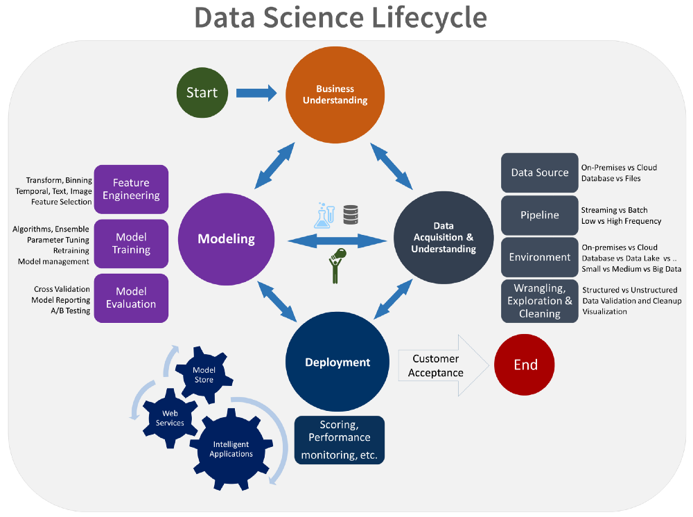

### Feature Engineering

**Steps:**

1. Missing Data (Imputation Technique) - Missing Data within Features of the dataset
2. Categorical Variables - Machine Learning Model requires numbers instead of String or Object
3. Variable Transformation - Linear Model assumes Features follow Normal or Gaussian Distribution
4. Discretisation - Converting Continuous numbers into Discrete numbers.
5. Outliers - outliers have huge impact on Linear Models.
6. Feature Scaling - All Features in one scale

**Feature Engineering Pipeline** - Creating Pipeline for all the Feature Engineering Steps using scikit-learn.

### Dataset - [House Prices: Advanced regression techniques](https://www.kaggle.com/c/house-prices-advanced-regression-techniques)

### Variable Types:

1. **Numerical - Discrete, Continuous**  
   a) Discrete - A variable whose values are whole numbers(counts) Ex: 1,2,3,4,5  
   b) Continuous - A variable that may contain any value within some range Ex: House Prices (\$1000, \$1501,\$2000,..)
2. **Categorical - Nominal, Ordinal**  
   a) Nominal - Variables in which categories can be meaningfully ordered. Ex: Student's Grade (A,B,C,D), Days of the week (Monday=0, Tuesday=1,..)  
   b) Ordinal - Variables which shows no intrinsic order of the lablels. Ex: Counties list, Cities List
3. **Mixed Variable - Both Strings and Numbers**  
   a) Numbers or labels in different observations - 1,2,3,'A','B'  
   b) Numbers or labels in same observations - '1A','2B','3C'
4. **Date and Time**  
   a) Date - '01-08-2020', '08/01/2020'  
   b) Time - '09.20.00 AM'  
   c) Date and Time - '01-08-2020 09.20.00'
5. **Text/Image**  
   a) Group of words  
   b) Images

```python
# Data Analysis/Data Visualization library
import numpy as np
import pandas as pd

import matplotlib.pyplot as plt
import seaborn as sns
%matplotlib inline

from sklearn.model_selection import train_test_split
from sklearn.impute import SimpleImputer, MissingIndicator
from sklearn.compose import ColumnTransformer
from sklearn.pipeline import Pipeline
from sklearn.preprocessing import OneHotEncoder, LabelEncoder, \
FunctionTransformer, PowerTransformer, KBinsDiscretizer, StandardScaler, MinMaxScaler

pd.set_option('display.max_columns', None)
```

```python
#Read Housing DataSet
housing_data = pd.read_csv(r'E:\Coding Nest\meetup\FeatureEngineering\house-prices-advanced-regression-techniques\train.csv')
```

```python
housing_data.head()
```

|  | Id | MSSubClass | MSZoning | LotFrontage | LotArea | Street | Alley | LotShape | LandContour | Utilities | LotConfig | LandSlope | Neighborhood | Condition1 | Condition2 | BldgType | HouseStyle | OverallQual | OverallCond | YearBuilt | YearRemodAdd | RoofStyle | RoofMatl | Exterior1st | Exterior2nd | MasVnrType | MasVnrArea | ExterQual | ExterCond | … |
| --- | --- | --- | --- | --- | --- | --- | --- | --- | --- | --- | --- | --- | --- | --- | --- | --- | --- | --- | --- | --- | --- | --- | --- | --- | --- | --- | --- | --- | --- | --- |
| 0 | 1 | 60 | RL | 65.0 | 8450 | Pave | NaN | Reg | Lvl | AllPub | Inside | Gtl | CollgCr | Norm | Norm | 1Fam | 2Story | 7 | 5 | 2003 | 2003 | Gable | CompShg | VinylSd | VinylSd | BrkFace | 196.0 | Gd | TA | … |
| 1 | 2 | 20 | RL | 80.0 | 9600 | Pave | NaN | Reg | Lvl | AllPub | FR2 | Gtl | Veenker | Feedr | Norm | 1Fam | 1Story | 6 | 8 | 1976 | 1976 | Gable | CompShg | MetalSd | MetalSd | None | 0.0 | TA | TA | … |
| 2 | 3 | 60 | RL | 68.0 | 11250 | Pave | NaN | IR1 | Lvl | AllPub | Inside | Gtl | CollgCr | Norm | Norm | 1Fam | 2Story | 7 | 5 | 2001 | 2002 | Gable | CompShg | VinylSd | VinylSd | BrkFace | 162.0 | Gd | TA | … |
| 3 | 4 | 70 | RL | 60.0 | 9550 | Pave | NaN | IR1 | Lvl | AllPub | Corner | Gtl | Crawfor | Norm | Norm | 1Fam | 2Story | 7 | 5 | 1915 | 1970 | Gable | CompShg | Wd Sdng | Wd Shng | None | 0.0 | TA | TA | … |
| 4 | 5 | 60 | RL | 84.0 | 14260 | Pave | NaN | IR1 | Lvl | AllPub | FR2 | Gtl | NoRidge | Norm | Norm | 1Fam | 2Story | 8 | 5 | 2000 | 2000 | Gable | CompShg | VinylSd | VinylSd | BrkFace | 350.0 | Gd | TA | … |

### 1. Missing Data Imputation

**Imputation is the act of replacing missing data with statistical estimates of the missing values.**  
**The Goal of any imputation technique is to produce a complete dataset that can be used to train machine learning models.**

**Numerical Variables**  
a) Mean/Median Imputation  
b) Arbitary Value Imputation/End of Tail Imputation

**Categorical Variables**  
a) Frequency Category Imputation  
b) Adding a "Missing" category

**Both**  
a) Adding a Missing Indicator

```python
# make a list of the variables that contain missing values
vars_with_na = [var for var in housing_data.columns if housing_data[var].isnull().sum()>1]

# print the variable name and the percentage of missing values
for var in vars_with_na:
    print(var, np.round(housing_data[var].isnull().mean(), 3),  '% missing values')
```

```
LotFrontage 0.177 % missing values
Alley 0.938 % missing values
MasVnrType 0.005 % missing values
MasVnrArea 0.005 % missing values
BsmtQual 0.025 % missing values
BsmtCond 0.025 % missing values
BsmtExposure 0.026 % missing values
BsmtFinType1 0.025 % missing values
BsmtFinType2 0.026 % missing values
FireplaceQu 0.473 % missing values
GarageType 0.055 % missing values
GarageYrBlt 0.055 % missing values
GarageFinish 0.055 % missing values
GarageQual 0.055 % missing values
GarageCond 0.055 % missing values
PoolQC 0.995 % missing values
Fence 0.808 % missing values
MiscFeature 0.963 % missing values
```

#### Numerical variables

```python
# list of numerical variables
num_vars = [var for var in housing_data.columns if housing_data[var].dtypes != 'O']

print('Number of numerical variables: ', len(num_vars))

# visualise the numerical variables
housing_data[num_vars].head()
```

```
Number of numerical variables:  38
```

|  | Id | MSSubClass | LotFrontage | LotArea | OverallQual | OverallCond | YearBuilt | YearRemodAdd | MasVnrArea | BsmtFinSF1 | BsmtFinSF2 | BsmtUnfSF | TotalBsmtSF | 1stFlrSF | 2ndFlrSF | LowQualFinSF | GrLivArea | BsmtFullBath | BsmtHalfBath | FullBath | HalfBath | BedroomAbvGr | KitchenAbvGr | TotRmsAbvGrd | Fireplaces | GarageYrBlt | GarageCars | GarageArea | WoodDeckSF | … |
| --- | --- | --- | --- | --- | --- | --- | --- | --- | --- | --- | --- | --- | --- | --- | --- | --- | --- | --- | --- | --- | --- | --- | --- | --- | --- | --- | --- | --- | --- | --- |
| 0 | 1 | 60 | 65.0 | 8450 | 7 | 5 | 2003 | 2003 | 196.0 | 706 | 0 | 150 | 856 | 856 | 854 | 0 | 1710 | 1 | 0 | 2 | 1 | 3 | 1 | 8 | 0 | 2003.0 | 2 | 548 | 0 | … |
| 1 | 2 | 20 | 80.0 | 9600 | 6 | 8 | 1976 | 1976 | 0.0 | 978 | 0 | 284 | 1262 | 1262 | 0 | 0 | 1262 | 0 | 1 | 2 | 0 | 3 | 1 | 6 | 1 | 1976.0 | 2 | 460 | 298 | … |
| 2 | 3 | 60 | 68.0 | 11250 | 7 | 5 | 2001 | 2002 | 162.0 | 486 | 0 | 434 | 920 | 920 | 866 | 0 | 1786 | 1 | 0 | 2 | 1 | 3 | 1 | 6 | 1 | 2001.0 | 2 | 608 | 0 | … |
| 3 | 4 | 70 | 60.0 | 9550 | 7 | 5 | 1915 | 1970 | 0.0 | 216 | 0 | 540 | 756 | 961 | 756 | 0 | 1717 | 1 | 0 | 1 | 0 | 3 | 1 | 7 | 1 | 1998.0 | 3 | 642 | 0 | … |
| 4 | 5 | 60 | 84.0 | 14260 | 8 | 5 | 2000 | 2000 | 350.0 | 655 | 0 | 490 | 1145 | 1145 | 1053 | 0 | 2198 | 1 | 0 | 2 | 1 | 4 | 1 | 9 | 1 | 2000.0 | 3 | 836 | 192 | … |

#### Temoral Variables

```python
# list of variables that contain year information
year_vars = [var for var in num_vars if 'Yr' in var or 'Year' in var]

print(year_vars)
```

```
['YearBuilt', 'YearRemodAdd', 'GarageYrBlt', 'YrSold']
```

#### Discrete Variables

```python
#list of discrete variables
discrete_vars = [var for var in num_vars if len(housing_data[var].unique())<20 and var not in year_vars+['Id']]

print('Number of discrete variables: ', len(discrete_vars))
```

```
Number of discrete variables:  14
```

#### Continuous Variables

```python
# list of continuous variables
cont_vars = [var for var in num_vars if var not in discrete_vars+year_vars+['Id']]

print('Number of continuous variables: ', len(cont_vars))
```

```
Number of continuous variables:  19
```

#### Missing Numerical Variables

```python
# make a list of the numerical variables that contain missing values
vars_with_na = [var for var in num_vars if housing_data[var].isnull().sum()>1]

# print the variable name and the percentage of missing values
for var in vars_with_na:
    print(var, np.round(housing_data[var].isnull().mean(), 3),  ' % missing values')
```

```
LotFrontage 0.177  % missing values
MasVnrArea 0.005  % missing values
GarageYrBlt 0.055  % missing values
```

### Categorical variables

```python
### Categorical variables
cat_vars = [var for var in housing_data.columns if housing_data[var].dtypes=='O']

print('Number of categorical variables: ', len(cat_vars))
```

```
Number of categorical variables:  43
```

#### Missing Categorical variables

```python
# make a list of the categorical variables that contain missing values
vars_with_na = [var for var in cat_vars if housing_data[var].isnull().sum()>1]

# print the variable name and the percentage of missing values
for var in vars_with_na:
    print(var, np.round(housing_data[var].isnull().mean(), 3),'% missing values')
```

```
Alley 0.938 % missing values
MasVnrType 0.005 % missing values
BsmtQual 0.025 % missing values
BsmtCond 0.025 % missing values
BsmtExposure 0.026 % missing values
BsmtFinType1 0.025 % missing values
BsmtFinType2 0.026 % missing values
FireplaceQu 0.473 % missing values
GarageType 0.055 % missing values
GarageFinish 0.055 % missing values
GarageQual 0.055 % missing values
GarageCond 0.055 % missing values
PoolQC 0.995 % missing values
Fence 0.808 % missing values
MiscFeature 0.963 % missing values
```

#### Number of Labels: cardinality

```python
for var in cat_vars:
    print(var, len(housing_data[var].unique()), ' categories')
```

```
MSZoning 5  categories
Street 2  categories
Alley 3  categories
LotShape 4  categories
LandContour 4  categories
Utilities 2  categories
LotConfig 5  categories
LandSlope 3  categories
Neighborhood 25  categories
Condition1 9  categories
Condition2 8  categories
BldgType 5  categories
HouseStyle 8  categories
RoofStyle 6  categories
RoofMatl 8  categories
Exterior1st 15  categories
Exterior2nd 16  categories
MasVnrType 5  categories
ExterQual 4  categories
ExterCond 5  categories
Foundation 6  categories
BsmtQual 5  categories
BsmtCond 5  categories
BsmtExposure 5  categories
BsmtFinType1 7  categories
BsmtFinType2 7  categories
Heating 6  categories
HeatingQC 5  categories
CentralAir 2  categories
Electrical 6  categories
KitchenQual 4  categories
Functional 7  categories
FireplaceQu 6  categories
GarageType 7  categories
GarageFinish 4  categories
GarageQual 6  categories
GarageCond 6  categories
PavedDrive 3  categories
PoolQC 4  categories
Fence 5  categories
MiscFeature 5  categories
SaleType 9  categories
SaleCondition 6  categories
```

#### Rare Labels

```python
def analyse_rare_labels(df, var, rare_perc):
    df = df.copy()
    tmp = df.groupby(var)['SalePrice'].count() / len(df)
    return tmp[tmp<rare_perc]

for var in cat_vars:
    print(analyse_rare_labels(housing_data, var, 0.05))
```

```
MSZoning
C (all)    0.006849
FV         0.044521
RH         0.010959
Name: SalePrice, dtype: float64
Street
Grvl    0.00411
Name: SalePrice, dtype: float64
Alley
Grvl    0.034247
Pave    0.028082
Name: SalePrice, dtype: float64
LotShape
IR2    0.028082
IR3    0.006849
Name: SalePrice, dtype: float64
LandContour
Bnk    0.043151
HLS    0.034247
Low    0.024658
Name: SalePrice, dtype: float64
Utilities
NoSeWa    0.000685
Name: SalePrice, dtype: float64
LotConfig
FR2    0.032192
FR3    0.002740
Name: SalePrice, dtype: float64
LandSlope
Mod    0.044521
Sev    0.008904
Name: SalePrice, dtype: float64
Neighborhood
Blmngtn    0.011644
Blueste    0.001370
BrDale     0.010959
BrkSide    0.039726
ClearCr    0.019178
Crawfor    0.034932
IDOTRR     0.025342
```

[output cut: 183 more lines]

```
Name: SalePrice, dtype: float64
SaleType
COD      0.029452
CWD      0.002740
Con      0.001370
ConLD    0.006164
ConLI    0.003425
ConLw    0.003425
Oth      0.002055
Name: SalePrice, dtype: float64
SaleCondition
AdjLand    0.002740
Alloca     0.008219
Family     0.013699
Name: SalePrice, dtype: float64
```

```python
# let's separate into training and testing set
X_train, X_test, y_train, y_test = train_test_split(
    housing_data.drop('SalePrice',axis=1),  # predictors
    housing_data['SalePrice'],  # target
    test_size=0.3,  # percentage of obs in test set
    random_state=0)  # seed to ensure reproducibility

X_train.shape, X_test.shape
```

```
((1022, 80), (438, 80))
```

### Mean/Median Imputation

**Mean/Median imputation consists of replacing all occurrences of missing values (NA) within a variable by the mean (if the variable has a Gaussian distribution) or median (if the variable has a skewed distribution).**

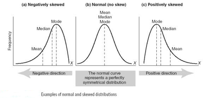

#### Distribution of features having missing values

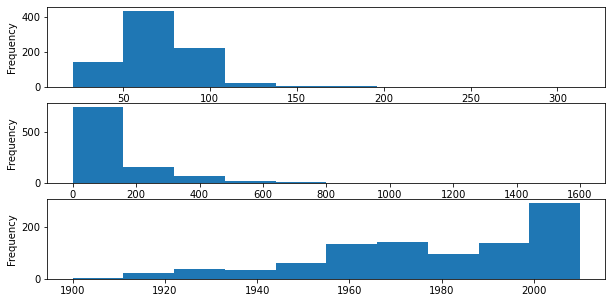

```python
fig,axes= plt.subplots(nrows=3,ncols=1, figsize=(10,5))

X_train['LotFrontage'].plot(kind='hist', ax=axes[0])
X_train['MasVnrArea'].plot(kind='hist', ax=axes[1])
X_train['GarageYrBlt'].plot(kind='hist', ax=axes[2]);
```

#### Using Pandas

```python
# Function to impute missing values
def impute_na(df, variable, value):
    return df[variable].fillna(value)
```

```python
lotfrontage_mean = X_train['LotFrontage'].mean()
masvnrarea_median = X_train['MasVnrArea'].median()
garageyrblt_median = X_train['GarageYrBlt'].median()
```

```python
#'LotFrontage' column
X_train['LotFrontage'] = impute_na(X_train, 'LotFrontage', lotfrontage_mean)
X_test['LotFrontage'] = impute_na(X_test, 'LotFrontage', lotfrontage_mean)

#'MasVnrArea' column
X_train['MasVnrArea'] = impute_na(X_train, 'MasVnrArea', masvnrarea_median)
X_test['MasVnrArea'] = impute_na(X_test, 'MasVnrArea', masvnrarea_median)

#'GarageYrBlt' column
X_train['GarageYrBlt'] = impute_na(X_train, 'GarageYrBlt', garageyrblt_median)
X_test['GarageYrBlt'] = impute_na(X_test, 'GarageYrBlt', garageyrblt_median)
```

```python
X_train[['LotFrontage',  'MasVnrArea', 'GarageYrBlt']].isnull().mean()
```

```
LotFrontage    0.0
MasVnrArea     0.0
GarageYrBlt    0.0
dtype: float64
```

#### using scikit-learn

```python
# let's separate into training and testing set
X_train, X_test, y_train, y_test = train_test_split(
    housing_data.drop('SalePrice',axis=1),  # predictors
    housing_data['SalePrice'],  # target
    test_size=0.3,  # percentage of obs in test set
    random_state=0)  # seed to ensure reproducibility

X_train.shape, X_test.shape
```

```
((1022, 80), (438, 80))
```

```python
numeric_features_mean = ['LotFrontage']
numeric_features_median = ['MasVnrArea', 'GarageYrBlt']

numeric_mean_imputer = Pipeline(steps=[
    ('imputer', SimpleImputer(strategy='mean')),
])

numeric_median_imputer = Pipeline(steps=[
    ('imputer', SimpleImputer(strategy='median')),
])

preprocessor = ColumnTransformer(transformers=[
    ('mean_imputer', numeric_mean_imputer, numeric_features_mean),
    ('median_imputer', numeric_median_imputer, numeric_features_median)
])

preprocessor.fit(X_train)
```

```
ColumnTransformer(transformers=[('mean_imputer',
                                 Pipeline(steps=[('imputer', SimpleImputer())]),
                                 ['LotFrontage']),
                                ('median_imputer',
                                 Pipeline(steps=[('imputer',
                                                  SimpleImputer(strategy='median'))]),
                                 ['MasVnrArea', 'GarageYrBlt'])])
```

```python
X_train = preprocessor.transform(X_train)

np.mean(np.isnan(X_train))
```

```
0.0
```

```python
X_test = preprocessor.transform(X_test)

np.mean(np.isnan(X_test))
```

```
0.0
```

### Arbitary Value Imputation

**Arbitrary value imputation consists of replacing all occurrences of missing values (NA) within a variable by an arbitrary value. Typically used arbitrary values are 0, 999, -999 (or other combinations of 9s) or -1 (if the distribution is positive).**

```python
# let's separate into training and testing set
X_train, X_test, y_train, y_test = train_test_split(
    housing_data.drop('SalePrice',axis=1),  # predictors
    housing_data['SalePrice'],  # target
    test_size=0.3,  # percentage of obs in test set
    random_state=0)  # seed to ensure reproducibility

X_train.shape, X_test.shape
```

```
((1022, 80), (438, 80))
```

```python
features_LotFrontAge = ['LotFrontage']
features_MasVnrArea = ['MasVnrArea']
features_GarageYrBlt = ['GarageYrBlt']

imputer_LotFrontAge = Pipeline(steps=[
    ('imputer', SimpleImputer(strategy='constant', fill_value = 999)),
])

imputer_MasVnrArea = Pipeline(steps=[
    ('imputer', SimpleImputer(strategy='constant', fill_value = -10)),
])

imputer_GarageYrBlt = Pipeline(steps=[
    ('imputer', SimpleImputer(strategy='constant', fill_value = 1700)),
])

preprocessor = ColumnTransformer(transformers=[
    ('imputer_LotFrontAge', imputer_LotFrontAge, features_LotFrontAge),
    ('imputer_MasVnrArea', imputer_MasVnrArea, features_MasVnrArea),
    ('imputer_GarageYrBlt', imputer_GarageYrBlt, features_GarageYrBlt)
])
```

```python
# now we fit the preprocessor
preprocessor.fit(X_train)
```

```
ColumnTransformer(transformers=[('imputer_LotFrontAge',
                                 Pipeline(steps=[('imputer',
                                                  SimpleImputer(fill_value=999,
                                                                strategy='constant'))]),
                                 ['LotFrontage']),
                                ('imputer_MasVnrArea',
                                 Pipeline(steps=[('imputer',
                                                  SimpleImputer(fill_value=-10,
                                                                strategy='constant'))]),
                                 ['MasVnrArea']),
                                ('imputer_GarageYrBlt',
                                 Pipeline(steps=[('imputer',
                                                  SimpleImputer(fill_value=1700,
                                                                strategy='constant'))]),
                                 ['GarageYrBlt'])])
```

```python
# and now we can impute the data
X_train = preprocessor.transform(X_train)
X_test = preprocessor.transform(X_test)

np.mean(np.isnan(X_train))
```

```
0.0
```

```python
np.mean(np.isnan(X_test))
```

```
0.0
```

### Frequent Category Imputation (mode)

```python
# let's separate into training and testing set
X_train, X_test, y_train, y_test = train_test_split(
    housing_data.drop('SalePrice',axis=1),  # predictors
    housing_data['SalePrice'],  # target
    test_size=0.3,  # percentage of obs in test set
    random_state=0)  # seed to ensure reproducibility

X_train.shape, X_test.shape
```

```
((1022, 80), (438, 80))
```

```python
features_categoric = ['Alley','MasVnrType','BsmtQual','BsmtCond','BsmtExposure','BsmtFinType1','BsmtFinType2',
                     'FireplaceQu','GarageType','GarageFinish','GarageQual','GarageCond','PoolQC',
                     'Fence','MiscFeature']

categoric_imputer = Pipeline(steps=[
    ('imputer', SimpleImputer(strategy='most_frequent')),
])

preprocessor = ColumnTransformer(transformers=[
    ('categoric_imputer', categoric_imputer, features_categoric)
])
```

```python
# now we fit the preprocessor
preprocessor.fit(X_train)
```

```
ColumnTransformer(transformers=[('categoric_imputer',
                                 Pipeline(steps=[('imputer',
                                                  SimpleImputer(strategy='most_frequent'))]),
                                 ['Alley', 'MasVnrType', 'BsmtQual', 'BsmtCond',
                                  'BsmtExposure', 'BsmtFinType1',
                                  'BsmtFinType2', 'FireplaceQu', 'GarageType',
                                  'GarageFinish', 'GarageQual', 'GarageCond',
                                  'PoolQC', 'Fence', 'MiscFeature'])])
```

```python
preprocessor.named_transformers_['categoric_imputer'].named_steps['imputer'].statistics_
```

```
array(['Pave', 'None', 'TA', 'TA', 'No', 'Unf', 'Unf', 'Gd', 'Attchd',
       'Unf', 'TA', 'TA', 'Gd', 'MnPrv', 'Shed'], dtype=object)
```

```python
# and now we can impute the data
X_train = preprocessor.transform(X_train)
X_test = preprocessor.transform(X_test)
```

#### Missing Category Imputation ('missing')

```python
# let's separate into training and testing set
X_train, X_test, y_train, y_test = train_test_split(
    housing_data.drop('SalePrice',axis=1),  # predictors
    housing_data['SalePrice'],  # target
    test_size=0.3,  # percentage of obs in test set
    random_state=0)  # seed to ensure reproducibility

X_train.shape, X_test.shape
```

```
((1022, 80), (438, 80))
```

```python
features_categoric = ['Alley','MasVnrType','BsmtQual','BsmtCond','BsmtExposure','BsmtFinType1','BsmtFinType2',
                     'FireplaceQu','GarageType','GarageFinish','GarageQual','GarageCond','PoolQC',
                     'Fence','MiscFeature']


imputer_categoric = Pipeline(
    steps=[('imputer',
            SimpleImputer(strategy='constant', fill_value='Missing'))])

# then we put the features list and the transformers together
# using the column transformer

preprocessor = ColumnTransformer(transformers=[('imputer_categoric',
                                                imputer_categoric,
                                                features_categoric)])
```

```python
# now we fit the preprocessor
preprocessor.fit(X_train)
```

```
ColumnTransformer(transformers=[('imputer_categoric',
                                 Pipeline(steps=[('imputer',
                                                  SimpleImputer(fill_value='Missing',
                                                                strategy='constant'))]),
                                 ['Alley', 'MasVnrType', 'BsmtQual', 'BsmtCond',
                                  'BsmtExposure', 'BsmtFinType1',
                                  'BsmtFinType2', 'FireplaceQu', 'GarageType',
                                  'GarageFinish', 'GarageQual', 'GarageCond',
                                  'PoolQC', 'Fence', 'MiscFeature'])])
```

```python
preprocessor.named_transformers_['imputer_categoric'].named_steps['imputer'].statistics_
```

```
array(['Missing', 'Missing', 'Missing', 'Missing', 'Missing', 'Missing',
       'Missing', 'Missing', 'Missing', 'Missing', 'Missing', 'Missing',
       'Missing', 'Missing', 'Missing'], dtype=object)
```

```python
# and now we can impute the data
# remember it returs a numpy array

X_train = preprocessor.transform(X_train)
X_test = preprocessor.transform(X_test)
```

#### Missing Indicator

Scikit-learn provides the MissingIndicator class to add a binary variable that flags NA.

The MissingIndicator has the option of adding a Missing indicator binary variable to all the variables in the dataset, or only those that show NA in the train set.

```python
# let's separate into training and testing set
X_train, X_test, y_train, y_test = train_test_split(
    housing_data.drop('SalePrice',axis=1),  # predictors
    housing_data['SalePrice'],  # target
    test_size=0.3,  # percentage of obs in test set
    random_state=0)  # seed to ensure reproducibility

X_train.shape, X_test.shape
```

```
((1022, 80), (438, 80))
```

```python
indicator = MissingIndicator(error_on_new=True, features='missing-only')
indicator.fit(X_train)
```

```
MissingIndicator()
```

```python
indicator.features_
```

```
array([ 3,  6, 25, 26, 30, 31, 32, 33, 35, 42, 57, 58, 59, 60, 63, 64, 72,
       73, 74], dtype=int64)
```

```python
X_train.columns[indicator.features_]
```

```
Index(['LotFrontage', 'Alley', 'MasVnrType', 'MasVnrArea', 'BsmtQual',
       'BsmtCond', 'BsmtExposure', 'BsmtFinType1', 'BsmtFinType2',
       'Electrical', 'FireplaceQu', 'GarageType', 'GarageYrBlt',
       'GarageFinish', 'GarageQual', 'GarageCond', 'PoolQC', 'Fence',
       'MiscFeature'],
      dtype='object')
```

```python
tmp = indicator.transform(X_train)

tmp
```

```
array([[ True,  True, False, ...,  True, False,  True],
       [ True,  True, False, ...,  True,  True,  True],
       [False,  True, False, ...,  True,  True,  True],
       ...,
       [False,  True, False, ...,  True,  True,  True],
       [ True,  True, False, ...,  True,  True,  True],
       [False,  True, False, ...,  True,  True,  True]])
```

```python
# so we need to join it manually to the original X_train

# let's create a column name for each of the new MissingIndicators
indicator_cols = [c+'_NA' for c in X_train.columns[indicator.features_]]

# and now we concatenate
X_train = pd.concat([
    X_train.reset_index(),
    pd.DataFrame(tmp, columns = indicator_cols)],
    axis=1)

X_train.head()
```

|  | index | Id | MSSubClass | MSZoning | LotFrontage | LotArea | Street | Alley | LotShape | LandContour | Utilities | LotConfig | LandSlope | Neighborhood | Condition1 | Condition2 | BldgType | HouseStyle | OverallQual | OverallCond | YearBuilt | YearRemodAdd | RoofStyle | RoofMatl | Exterior1st | Exterior2nd | MasVnrType | MasVnrArea | ExterQual | … |
| --- | --- | --- | --- | --- | --- | --- | --- | --- | --- | --- | --- | --- | --- | --- | --- | --- | --- | --- | --- | --- | --- | --- | --- | --- | --- | --- | --- | --- | --- | --- |
| 0 | 64 | 65 | 60 | RL | NaN | 9375 | Pave | NaN | Reg | Lvl | AllPub | Inside | Gtl | CollgCr | Norm | Norm | 1Fam | 2Story | 7 | 5 | 1997 | 1998 | Gable | CompShg | VinylSd | VinylSd | BrkFace | 573.0 | TA | … |
| 1 | 682 | 683 | 120 | RL | NaN | 2887 | Pave | NaN | Reg | HLS | AllPub | Inside | Gtl | ClearCr | Norm | Norm | 1Fam | 1Story | 6 | 5 | 1996 | 1997 | Gable | CompShg | Wd Sdng | Wd Sdng | None | 0.0 | TA | … |
| 2 | 960 | 961 | 20 | RL | 50.0 | 7207 | Pave | NaN | IR1 | Lvl | AllPub | Inside | Gtl | BrkSide | Norm | Norm | 1Fam | 1Story | 5 | 7 | 1958 | 2008 | Gable | CompShg | Wd Sdng | Plywood | None | 0.0 | TA | … |
| 3 | 1384 | 1385 | 50 | RL | 60.0 | 9060 | Pave | NaN | Reg | Lvl | AllPub | Inside | Gtl | Edwards | Norm | Norm | 1Fam | 1.5Fin | 6 | 5 | 1939 | 1950 | Gable | CompShg | WdShing | Wd Shng | None | 0.0 | TA | … |
| 4 | 1100 | 1101 | 30 | RL | 60.0 | 8400 | Pave | NaN | Reg | Bnk | AllPub | Inside | Gtl | SWISU | Norm | Norm | 1Fam | 1Story | 2 | 5 | 1920 | 1950 | Gable | CompShg | Wd Sdng | Wd Sdng | None | 0.0 | TA | … |

```python
# now the same for the test set
tmp = indicator.transform(X_test)

X_test = pd.concat([
    X_test.reset_index(),
    pd.DataFrame(tmp, columns = indicator_cols)],
    axis=1)

X_test.head()
```

|  | index | Id | MSSubClass | MSZoning | LotFrontage | LotArea | Street | Alley | LotShape | LandContour | Utilities | LotConfig | LandSlope | Neighborhood | Condition1 | Condition2 | BldgType | HouseStyle | OverallQual | OverallCond | YearBuilt | YearRemodAdd | RoofStyle | RoofMatl | Exterior1st | Exterior2nd | MasVnrType | MasVnrArea | ExterQual | … |
| --- | --- | --- | --- | --- | --- | --- | --- | --- | --- | --- | --- | --- | --- | --- | --- | --- | --- | --- | --- | --- | --- | --- | --- | --- | --- | --- | --- | --- | --- | --- |
| 0 | 529 | 530 | 20 | RL | NaN | 32668 | Pave | NaN | IR1 | Lvl | AllPub | CulDSac | Gtl | Crawfor | Norm | Norm | 1Fam | 1Story | 6 | 3 | 1957 | 1975 | Hip | CompShg | Wd Sdng | Stone | NaN | NaN | Gd | … |
| 1 | 491 | 492 | 50 | RL | 79.0 | 9490 | Pave | NaN | Reg | Lvl | AllPub | Inside | Gtl | NAmes | Artery | Norm | 1Fam | 1.5Fin | 6 | 7 | 1941 | 1950 | Gable | CompShg | Wd Sdng | Wd Sdng | None | 0.0 | TA | … |
| 2 | 459 | 460 | 50 | RL | NaN | 7015 | Pave | NaN | IR1 | Bnk | AllPub | Corner | Gtl | BrkSide | Norm | Norm | 1Fam | 1.5Fin | 5 | 4 | 1950 | 1950 | Gable | CompShg | MetalSd | MetalSd | BrkCmn | 161.0 | TA | … |
| 3 | 279 | 280 | 60 | RL | 83.0 | 10005 | Pave | NaN | Reg | Lvl | AllPub | Inside | Gtl | ClearCr | Norm | Norm | 1Fam | 2Story | 7 | 5 | 1977 | 1977 | Hip | CompShg | Plywood | Plywood | BrkFace | 299.0 | TA | … |
| 4 | 655 | 656 | 160 | RM | 21.0 | 1680 | Pave | NaN | Reg | Lvl | AllPub | Inside | Gtl | BrDale | Norm | Norm | Twnhs | 2Story | 6 | 5 | 1971 | 1971 | Gable | CompShg | HdBoard | ImStucc | BrkFace | 381.0 | TA | … |

#### SimpleImputer on entire DataSet

```python
imputer = SimpleImputer(strategy='most_frequent')

# we fit the imputer to the train set
imputer.fit(X_train)
```

```
SimpleImputer(strategy='most_frequent')
```

```python
X_train = imputer.transform(X_train)
X_test = imputer.transform(X_test)

X_train
```

```
array([[64, 65, 60, ..., True, False, True],
       [682, 683, 120, ..., True, True, True],
       [960, 961, 20, ..., True, True, True],
       ...,
       [1216, 1217, 90, ..., True, True, True],
       [559, 560, 120, ..., True, True, True],
       [684, 685, 60, ..., True, True, True]], dtype=object)
```

### 2. Categorical Variables Encoding

a) One-Hot-Encoding  
b) Label Encoding  
c) Rare Label Encoding

#### One-Hot Encoding

One hot encoding, consists in encoding each categorical variable with different boolean variables (also called dummy variables) which take values 0 or 1, indicating if a category is present in an observation.

For example, for the categorical variable "Gender", with labels 'female' and 'male', we can generate the boolean variable "female", which takes 1 if the person is 'female' or 0 otherwise, or we can generate the variable "male", which takes 1 if the person is 'male' and 0 otherwise.

```python
# let's separate into training and testing set
X_train, X_test, y_train, y_test = train_test_split(
    housing_data.drop('SalePrice',axis=1),  # predictors
    housing_data['SalePrice'],  # target
    test_size=0.3,  # percentage of obs in test set
    random_state=0)  # seed to ensure reproducibility

X_train.shape, X_test.shape
```

```
((1022, 80), (438, 80))
```

```python
columns = X_train.columns
```

```python
numeric_features_mean = ['LotFrontage']
numeric_features_median = ['MasVnrArea', 'GarageYrBlt']
features_categoric = ['Alley','MasVnrType','BsmtQual','BsmtCond','BsmtExposure','BsmtFinType1','BsmtFinType2',
                     'FireplaceQu','GarageType','GarageFinish','GarageQual','GarageCond','PoolQC',
                     'Fence','MiscFeature']


numeric_mean_imputer = Pipeline(steps=[
    ('imputer', SimpleImputer(strategy='mean')),
])

numeric_median_imputer = Pipeline(steps=[
    ('imputer', SimpleImputer(strategy='median')),
])

categoric_imputer = Pipeline(
    steps=[('imputer',
            SimpleImputer(strategy='constant', fill_value='Missing'))])


preprocessor = ColumnTransformer(transformers=[
    ('mean_imputer', numeric_mean_imputer, numeric_features_mean),
    ('median_imputer', numeric_median_imputer, numeric_features_median),
    ('categoric_imputer', categoric_imputer, features_categoric)
], remainder='passthrough')
```

```python
# now we fit the preprocessor
preprocessor.fit(X_train)
```

```
ColumnTransformer(remainder='passthrough',
                  transformers=[('mean_imputer',
                                 Pipeline(steps=[('imputer', SimpleImputer())]),
                                 ['LotFrontage']),
                                ('median_imputer',
                                 Pipeline(steps=[('imputer',
                                                  SimpleImputer(strategy='median'))]),
                                 ['MasVnrArea', 'GarageYrBlt']),
                                ('categoric_imputer',
                                 Pipeline(steps=[('imputer',
                                                  SimpleImputer(fill_value='Missing',
                                                                strategy='constant'))]),
                                 ['Alley', 'MasVnrType', 'BsmtQual', 'BsmtCond',
                                  'BsmtExposure', 'BsmtFinType1',
                                  'BsmtFinType2', 'FireplaceQu', 'GarageType',
                                  'GarageFinish', 'GarageQual', 'GarageCond',
                                  'PoolQC', 'Fence', 'MiscFeature'])])
```

```python
X_train = preprocessor.transform(X_train)
X_test = preprocessor.transform(X_test)
```

```python
X_train.shape,X_test.shape
```

```
((1022, 80), (438, 80))
```

```python
X_train = pd.DataFrame(data=X_train,columns=columns)
X_test = pd.DataFrame(data=X_test,columns=columns)

X_train.head()
```

|  | Id | MSSubClass | MSZoning | LotFrontage | LotArea | Street | Alley | LotShape | LandContour | Utilities | LotConfig | LandSlope | Neighborhood | Condition1 | Condition2 | BldgType | HouseStyle | OverallQual | OverallCond | YearBuilt | YearRemodAdd | RoofStyle | RoofMatl | Exterior1st | Exterior2nd | MasVnrType | MasVnrArea | ExterQual | ExterCond | … |
| --- | --- | --- | --- | --- | --- | --- | --- | --- | --- | --- | --- | --- | --- | --- | --- | --- | --- | --- | --- | --- | --- | --- | --- | --- | --- | --- | --- | --- | --- | --- |
| 0 | 69.6687 | 573 | 1998 | Missing | BrkFace | Gd | TA | No | GLQ | Unf | Missing | Attchd | RFn | TA | TA | Missing | GdPrv | Missing | 65 | 60 | RL | 9375 | Pave | Reg | Lvl | AllPub | Inside | Gtl | CollgCr | … |
| 1 | 69.6687 | 0 | 1996 | Missing | None | Gd | TA | Mn | GLQ | Unf | Gd | Attchd | Unf | TA | TA | Missing | Missing | Missing | 683 | 120 | RL | 2887 | Pave | Reg | HLS | AllPub | Inside | Gtl | ClearCr | … |
| 2 | 50 | 0 | 1979 | Missing | None | TA | TA | Gd | BLQ | Unf | Missing | Missing | Missing | Missing | Missing | Missing | Missing | Missing | 961 | 20 | RL | 7207 | Pave | IR1 | Lvl | AllPub | Inside | Gtl | BrkSide | … |
| 3 | 60 | 0 | 1939 | Missing | None | TA | TA | Mn | Rec | Unf | Missing | Detchd | Unf | TA | TA | Missing | MnPrv | Missing | 1385 | 50 | RL | 9060 | Pave | Reg | Lvl | AllPub | Inside | Gtl | Edwards | … |
| 4 | 60 | 0 | 1930 | Missing | None | TA | Fa | No | Rec | Unf | Missing | Detchd | Unf | TA | TA | Missing | Missing | Missing | 1101 | 30 | RL | 8400 | Pave | Reg | Bnk | AllPub | Inside | Gtl | SWISU | … |

```python
encoder = OneHotEncoder(categories='auto',
                       drop='first', # to return k-1, use drop=false to return k dummies
                       sparse=False,
                       handle_unknown='error')
encoder.fit(X_train.fillna('Missing'))
```

```
OneHotEncoder(drop='first', sparse=False)
```

```python
encoder.categories_
```

```
[array([ 21.        ,  24.        ,  30.        ,  32.        ,
         33.        ,  34.        ,  35.        ,  36.        ,
         37.        ,  38.        ,  39.        ,  40.        ,
         41.        ,  42.        ,  43.        ,  44.        ,
         45.        ,  46.        ,  47.        ,  48.        ,
         49.        ,  50.        ,  51.        ,  52.        ,
         53.        ,  54.        ,  55.        ,  56.        ,
         57.        ,  58.        ,  59.        ,  60.        ,
         61.        ,  62.        ,  63.        ,  64.        ,
         65.        ,  66.        ,  67.        ,  68.        ,
         69.        ,  69.66866747,  70.        ,  71.        ,
         72.        ,  73.        ,  74.        ,  75.        ,
         76.        ,  77.        ,  78.        ,  79.        ,
         80.        ,  81.        ,  82.        ,  83.        ,
         84.        ,  85.        ,  86.        ,  87.        ,
```

[output cut: 660 more lines]

```python
tmp = encoder.transform(X_train.fillna('Missing'))

pd.DataFrame(tmp).head()
```

|  | 0 | 1 | 2 | 3 | 4 | 5 | 6 | 7 | 8 | 9 | 10 | 11 | 12 | 13 | 14 | 15 | 16 | 17 | 18 | 19 | 20 | 21 | 22 | 23 | 24 | 25 | 26 | 27 | 28 | … |
| --- | --- | --- | --- | --- | --- | --- | --- | --- | --- | --- | --- | --- | --- | --- | --- | --- | --- | --- | --- | --- | --- | --- | --- | --- | --- | --- | --- | --- | --- | --- |
| 0 | 0.0 | 0.0 | 0.0 | 0.0 | 0.0 | 0.0 | 0.0 | 0.0 | 0.0 | 0.0 | 0.0 | 0.0 | 0.0 | 0.0 | 0.0 | 0.0 | 0.0 | 0.0 | 0.0 | 0.0 | 0.0 | 0.0 | 0.0 | 0.0 | 0.0 | 0.0 | 0.0 | 0.0 | 0.0 | … |
| 1 | 0.0 | 0.0 | 0.0 | 0.0 | 0.0 | 0.0 | 0.0 | 0.0 | 0.0 | 0.0 | 0.0 | 0.0 | 0.0 | 0.0 | 0.0 | 0.0 | 0.0 | 0.0 | 0.0 | 0.0 | 0.0 | 0.0 | 0.0 | 0.0 | 0.0 | 0.0 | 0.0 | 0.0 | 0.0 | … |
| 2 | 0.0 | 0.0 | 0.0 | 0.0 | 0.0 | 0.0 | 0.0 | 0.0 | 0.0 | 0.0 | 0.0 | 0.0 | 0.0 | 0.0 | 0.0 | 0.0 | 0.0 | 0.0 | 0.0 | 0.0 | 1.0 | 0.0 | 0.0 | 0.0 | 0.0 | 0.0 | 0.0 | 0.0 | 0.0 | … |
| 3 | 0.0 | 0.0 | 0.0 | 0.0 | 0.0 | 0.0 | 0.0 | 0.0 | 0.0 | 0.0 | 0.0 | 0.0 | 0.0 | 0.0 | 0.0 | 0.0 | 0.0 | 0.0 | 0.0 | 0.0 | 0.0 | 0.0 | 0.0 | 0.0 | 0.0 | 0.0 | 0.0 | 0.0 | 0.0 | … |
| 4 | 0.0 | 0.0 | 0.0 | 0.0 | 0.0 | 0.0 | 0.0 | 0.0 | 0.0 | 0.0 | 0.0 | 0.0 | 0.0 | 0.0 | 0.0 | 0.0 | 0.0 | 0.0 | 0.0 | 0.0 | 0.0 | 0.0 | 0.0 | 0.0 | 0.0 | 0.0 | 0.0 | 0.0 | 0.0 | … |

#### Label Encoding

```python
from collections import defaultdict

d = defaultdict(LabelEncoder)

 # Encoding the variable
train_transformed = X_train[['Alley','MasVnrType']].apply(lambda x: d[x.name].fit_transform(x))

# # Using the dictionary to encode future data
test_transformed = X_test[['Alley','MasVnrType']].apply(lambda x: d[x.name].transform(x))
```

```python
train_transformed
```

|  | Alley | MasVnrType |
| --- | --- | --- |
| 0 | 4 | 0 |
| 1 | 4 | 0 |
| 2 | 4 | 0 |
| 3 | 4 | 0 |
| 4 | 0 | 0 |
| ... | ... | ... |
| 1017 | 4 | 0 |
| 1018 | 4 | 0 |
| 1019 | 2 | 0 |
| 1020 | 4 | 0 |
| 1021 | 4 | 0 |

1022 rows × 2 columns

```python
def find_non_rare_labels(df, variable, tolerance):

    temp = df.groupby([variable])[variable].count() / len(df)

    non_rare = [x for x in temp.loc[temp>tolerance].index.values]

    return non_rare


def rare_encoding(X_train, X_test, variable, tolerance):

    X_train = X_train.copy()
    X_test = X_test.copy()

    # find the most frequent category
    frequent_cat = find_non_rare_labels(X_train, variable, tolerance)

    # re-group rare labels
    X_train[variable] = np.where(X_train[variable].isin(
        frequent_cat), X_train[variable], 'Rare')

    X_test[variable] = np.where(X_test[variable].isin(
        frequent_cat), X_test[variable], 'Rare')

    return X_train, X_test
```

```python
for variable in ['MSZoning','Street','Alley','LotShape','LandContour','Utilities','LotConfig','LandSlope',
                 'Neighborhood','Condition1','Condition2','BldgType','HouseStyle','RoofStyle',
                 'RoofMatl','Exterior1st','Exterior2nd']:
    X_train, X_test = rare_encoding(X_train, X_test, variable, 0.05)
```

```python
X_train['Exterior1st'].unique()
```

[output not shown]

### Variable Transformation (continuous variables)

1. Logarathmic
2. Exponential
3. Reciprocal
4. Square-root
5. Box-Cox - https://en.wikipedia.org/wiki/Power_transform#Box%E2%80%93Cox_transformation
6. Yeo-Johnson - https://en.wikipedia.org/wiki/Power_transform#Yeo%E2%80%93Johnson_transformation

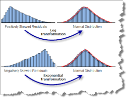

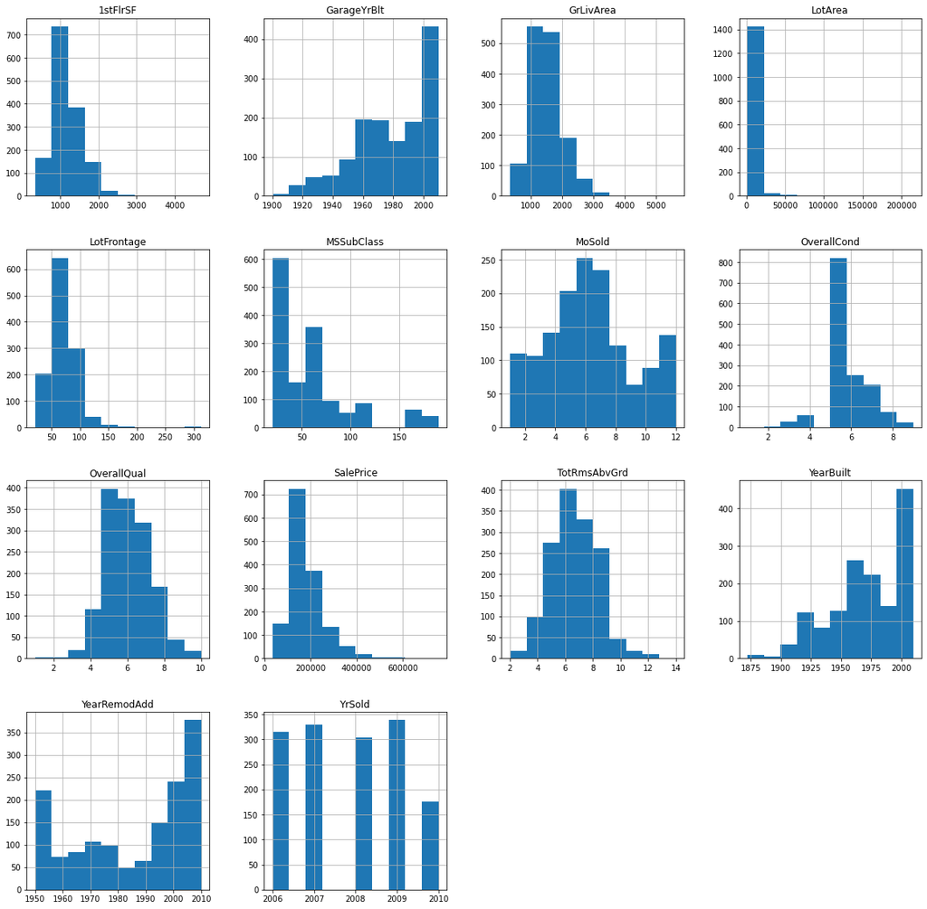

```python
cols = ['MSSubClass','LotFrontage', 'LotArea', 'OverallQual', 'OverallCond', 'YearBuilt', 'YearRemodAdd',
 '1stFlrSF', 'GrLivArea', 'TotRmsAbvGrd', 'GarageYrBlt', 'MoSold', 'YrSold', 'SalePrice']

housing_data[cols].hist(figsize=(20,20))
plt.show()
```

```python
import scipy.stats as stats

# plot the histograms to have a quick look at the variable distribution
# histogram and Q-Q plots

def diagnostic_plots(df, variable):

    # function to plot a histogram and a Q-Q plot
    # side by side, for a certain variable

    plt.figure(figsize=(15,6))
    plt.subplot(1, 2, 1)
    df[variable].hist(bins=30)

    plt.subplot(1, 2, 2)
    stats.probplot(df[variable], dist="norm", plot=plt)

    plt.show()
```

#### Logarithmic transformation

```python
# create a log transformer
transformer = FunctionTransformer(np.log, validate=True)
data_l = transformer.transform(housing_data[cols].fillna(1))
data_l = pd.DataFrame(data_l, columns = cols)
```

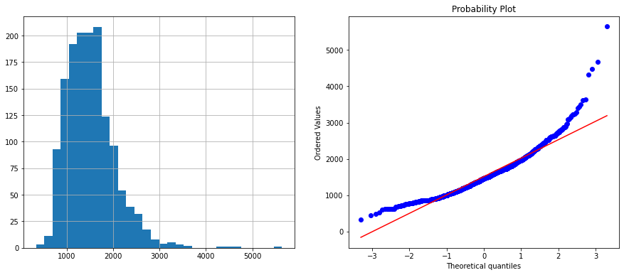

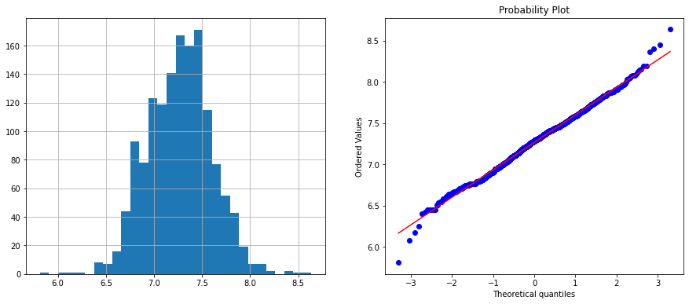

```python
# original distribution
diagnostic_plots(housing_data, 'GrLivArea')

#Logarithmic transformation
diagnostic_plots(data_l, 'GrLivArea')
```

#### Reciprocal Transformation

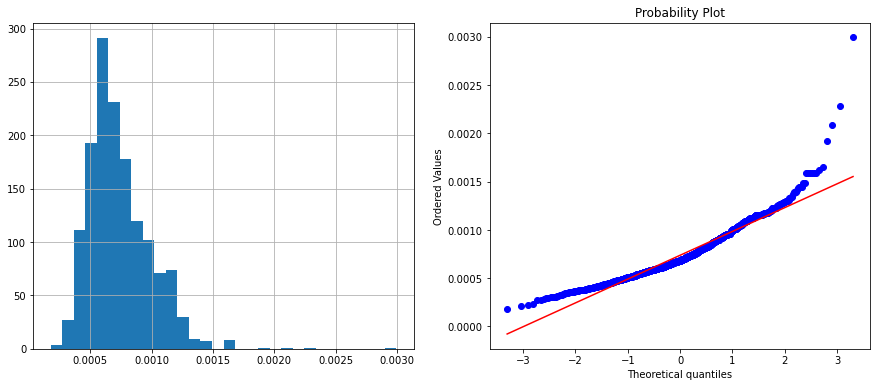

```python
# create a reciprocal transformer
transformer = FunctionTransformer(lambda x: 1/x, validate=True)
data_r = transformer.transform(housing_data[cols].fillna(1))
data_r = pd.DataFrame(data_r, columns = cols)

#Reciprocal Transformation
diagnostic_plots(data_r, 'GrLivArea')
```

#### Square-root Transformation

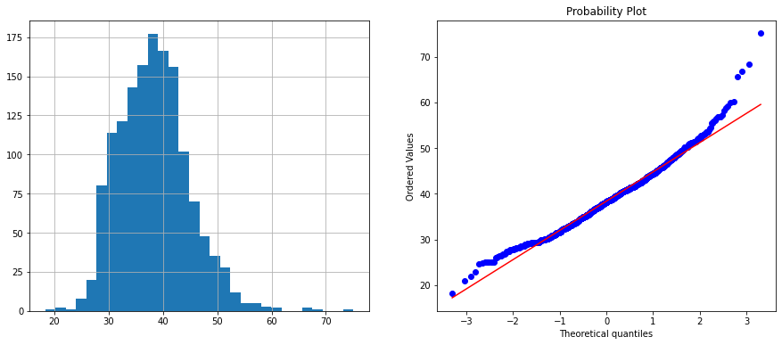

```python
# create a square-root transformer
transformer = FunctionTransformer(lambda x: x**(1/2), validate=True)
data_s = transformer.transform(housing_data[cols].fillna(1))
data_s = pd.DataFrame(data_s, columns = cols)

#Square-Root Transformation
diagnostic_plots(data_s, 'GrLivArea')
```

#### Exponential Transformation

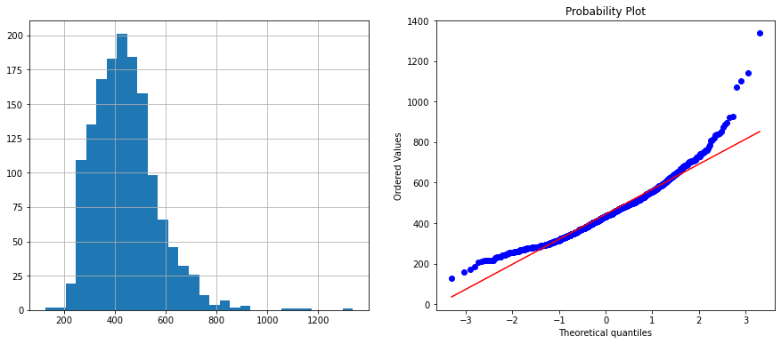

```python
# create a exponential transformer
transformer = FunctionTransformer(lambda x: x**(1/1.2), validate=True)
data_e = transformer.transform(housing_data[cols].fillna(1))
data_e = pd.DataFrame(data_e, columns = cols)

#Exponential Transformation
diagnostic_plots(data_e, 'GrLivArea')
```

#### Box-Cox Transformation

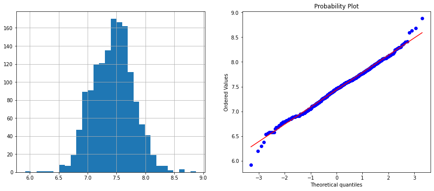

```python
# create the transformer
transformer = PowerTransformer(method='box-cox', standardize=False)

# find the optimal lambda using the train set
transformer.fit(housing_data[cols].fillna(1))

# transform the data
data_b = transformer.transform(housing_data[cols].fillna(1))

# capture data in a dataframe
data_b = pd.DataFrame(data_b, columns = cols)

diagnostic_plots(data_b, 'GrLivArea')
```

#### Yeo-Johnson Transformation

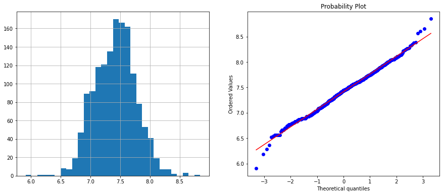

```python
# call the transformer
transformer = PowerTransformer(method='yeo-johnson', standardize=False)

# learn the lambda from the train set
transformer.fit(housing_data[cols].fillna(1))

# transform the data
data_y = transformer.transform(housing_data[cols].fillna(1))

# capture data in a dataframe
data_y = pd.DataFrame(data_y, columns = cols)

diagnostic_plots(data_y, 'GrLivArea')
```

### 4. Discretisation

It is the process of transforming continuous variables into discrete variables by creating a set of contiguous intervals that span the range of the variable's values. Discretisation is also called binning, where bin is an alternative name for intervals.

**Approaches:**

1. Equal Width
2. Equal Frequency
3. k-Means

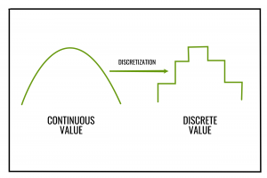

#### Equal-width Discretisation

```python
X_train['LowQualFinSF'].unique()
```

```
array([0, 764, 344, 972, 374, 230, 181, 294, 692, 600, 228, 336, 128, 438,
       352, 420, 354, 64, 239, 117, 290, 634, 380, 396, 180, 841, 1061,
       202, 630, 539, 1057, 215, 627, 163, 68, 232, 149, 121, 93, 123,
       532, 670, 127, 177, 479, 311, 193, 441, 287, 820, 472, 1029, 480,
       132, 435, 80, 81, 211, 150, 345, 182, 105, 557, 400, 531, 279, 110,
       276, 486, 119, 544, 168, 258, 551, 32, 96, 1085, 1080, 495, 1031,
       906, 606, 41, 1120, 682, 491, 28, 184, 35, 411, 362, 334, 273, 668,
       768, 306, 147, 375, 173, 108, 547, 106, 466, 492, 468, 324, 823,
       620, 791, 139, 208, 240, 612], dtype=object)
```

```python
disc = KBinsDiscretizer(n_bins=10, encode='ordinal', strategy='uniform')
disc.fit(X_train[['LowQualFinSF']])
```

```
KBinsDiscretizer(encode='ordinal', n_bins=10, strategy='uniform')
```

```python
disc.bin_edges_
```

```
array([array([   0.,  112.,  224.,  336.,  448.,  560.,  672.,  784.,  896.,
       1008., 1120.])], dtype=object)
```

```python
train_t = disc.transform(X_train[['LowQualFinSF']])
train_t = pd.DataFrame(train_t, columns = ['LowQualFinSF'])

train_t['LowQualFinSF'].value_counts()
```

```
0.0    913
1.0     29
4.0     18
2.0     18
3.0     18
5.0      9
9.0      7
7.0      4
6.0      4
8.0      2
Name: LowQualFinSF, dtype: int64
```

#### Equal Frequency Discretisation

```python
disc = KBinsDiscretizer(n_bins=10, encode='ordinal', strategy='quantile')

disc.fit(X_train[['LowQualFinSF']])
```

```
KBinsDiscretizer(encode='ordinal', n_bins=10)
```

```python
disc.bin_edges_
```

```
array([array([   0. ,  127.9, 1120. ])], dtype=object)
```

```python
train_t = disc.transform(X_train[['LowQualFinSF']])
train_t = pd.DataFrame(train_t, columns = ['LowQualFinSF'])

train_t['LowQualFinSF'].value_counts()
```

```
0.0    919
1.0    103
Name: LowQualFinSF, dtype: int64
```

#### k-Means Discretisation

```python
disc = KBinsDiscretizer(n_bins=5, encode='ordinal', strategy='kmeans')
disc.fit(X_train[['LowQualFinSF']])
```

```
KBinsDiscretizer(encode='ordinal', strategy='kmeans')
```

```python
disc.bin_edges_
```

```
array([array([   0.        ,   96.75001684,  316.4377014 ,  568.60216718,
        867.41503268, 1120.        ])], dtype=object)
```

```python
train_t = disc.transform(X_train[['LowQualFinSF']])
train_t = pd.DataFrame(train_t, columns = ['LowQualFinSF'])

train_t['LowQualFinSF'].value_counts()
```

```
0.0    909
1.0     49
2.0     38
3.0     17
4.0      9
Name: LowQualFinSF, dtype: int64
```

### 5. Handling Outliers

An outlier is a data point which is significantly different from the remaining data. Linear Model deviates if outliers are present

**Approaches:**

1. Trimming: Removing outliers from the dataset
2. Missing Data: Treat outliers as missing data and perform missing data imputation
3. Discretisation: Put Outliers into upper/lower bins and perform discretisation
4. Censoring: Capping both from top and bottom

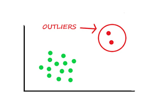

```python
# let's separate into training and testing set
X_train, X_test, y_train, y_test = train_test_split(
    housing_data.drop('SalePrice',axis=1),  # predictors
    housing_data['SalePrice'],  # target
    test_size=0.3,  # percentage of obs in test set
    random_state=0)  # seed to ensure reproducibility

X_train.shape, X_test.shape
```

```
((1022, 80), (438, 80))
```

```python
X_train.head()
```

|  | Id | MSSubClass | MSZoning | LotFrontage | LotArea | Street | Alley | LotShape | LandContour | Utilities | LotConfig | LandSlope | Neighborhood | Condition1 | Condition2 | BldgType | HouseStyle | OverallQual | OverallCond | YearBuilt | YearRemodAdd | RoofStyle | RoofMatl | Exterior1st | Exterior2nd | MasVnrType | MasVnrArea | ExterQual | ExterCond | … |
| --- | --- | --- | --- | --- | --- | --- | --- | --- | --- | --- | --- | --- | --- | --- | --- | --- | --- | --- | --- | --- | --- | --- | --- | --- | --- | --- | --- | --- | --- | --- |
| 64 | 65 | 60 | RL | NaN | 9375 | Pave | NaN | Reg | Lvl | AllPub | Inside | Gtl | CollgCr | Norm | Norm | 1Fam | 2Story | 7 | 5 | 1997 | 1998 | Gable | CompShg | VinylSd | VinylSd | BrkFace | 573.0 | TA | TA | … |
| 682 | 683 | 120 | RL | NaN | 2887 | Pave | NaN | Reg | HLS | AllPub | Inside | Gtl | ClearCr | Norm | Norm | 1Fam | 1Story | 6 | 5 | 1996 | 1997 | Gable | CompShg | Wd Sdng | Wd Sdng | None | 0.0 | TA | TA | … |
| 960 | 961 | 20 | RL | 50.0 | 7207 | Pave | NaN | IR1 | Lvl | AllPub | Inside | Gtl | BrkSide | Norm | Norm | 1Fam | 1Story | 5 | 7 | 1958 | 2008 | Gable | CompShg | Wd Sdng | Plywood | None | 0.0 | TA | Gd | … |
| 1384 | 1385 | 50 | RL | 60.0 | 9060 | Pave | NaN | Reg | Lvl | AllPub | Inside | Gtl | Edwards | Norm | Norm | 1Fam | 1.5Fin | 6 | 5 | 1939 | 1950 | Gable | CompShg | WdShing | Wd Shng | None | 0.0 | TA | TA | … |
| 1100 | 1101 | 30 | RL | 60.0 | 8400 | Pave | NaN | Reg | Bnk | AllPub | Inside | Gtl | SWISU | Norm | Norm | 1Fam | 1Story | 2 | 5 | 1920 | 1950 | Gable | CompShg | Wd Sdng | Wd Sdng | None | 0.0 | TA | TA | … |

```python
def diagnostic_plots(df, variable):
    # function takes a dataframe (df) and
    # the variable of interest as arguments

    # define figure size
    plt.figure(figsize=(16, 4))

    # histogram
    plt.subplot(1, 3, 1)
    sns.distplot(df[variable], bins=30)
    plt.title('Histogram')

    # Q-Q plot
    plt.subplot(1, 3, 2)
    stats.probplot(df[variable], dist="norm", plot=plt)
    plt.ylabel('Variable quantiles')

    # boxplot
    plt.subplot(1, 3, 3)
    sns.boxplot(y=df[variable])
    plt.title('Boxplot')

    plt.show()
```

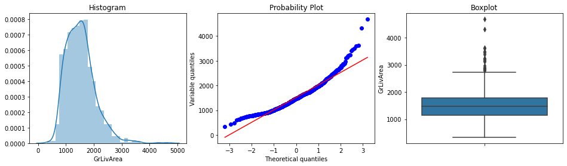

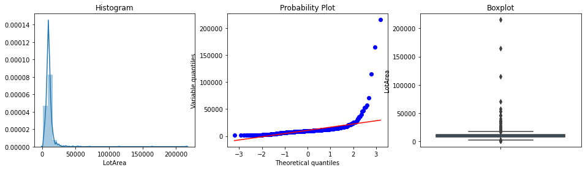

```python
diagnostic_plots(X_train, 'GrLivArea')
diagnostic_plots(X_train, 'LotArea')
```

```python
def find_skewed_boundaries(df, variable, distance):

    # Let's calculate the boundary ranges for skewed distributions
    IQR = df[variable].quantile(0.75) - df[variable].quantile(0.25)

    lower_boundary = df[variable].quantile(0.25) - (IQR * distance)
    upper_boundary = df[variable].quantile(0.75) + (IQR * distance)

    return upper_boundary, lower_boundary
```

```python
# find limits for LotArea
LA_upper_limit, LA_lower_limit = find_skewed_boundaries(X_train, 'LotArea', 1.5)
LA_upper_limit,LA_lower_limit
```

```
(17376.25, 1962.25)
```

```python
# find limits for GrLivArea
GLA_upper_limit, GLA_lower_limit = find_skewed_boundaries(X_train, 'GrLivArea', 1.5)
GLA_upper_limit, GLA_lower_limit
```

```
(2764.625, 165.625)
```

```python
# let's flag the outliers in the data set

outliers_LA = np.where(X_train['LotArea'] > LA_upper_limit, True,
                       np.where(X_train['LotArea'] < LA_lower_limit, True, False))
```

```python
# let's flag the outliers in the data set

outliers_GLA = np.where(X_train['GrLivArea'] > GLA_upper_limit, True,
                       np.where(X_train['GrLivArea'] < GLA_lower_limit, True, False))
```

```python
# let's trim the dataset

X_train_trimmed = X_train.loc[~(outliers_LA + outliers_GLA), ]

X_train.shape, X_train_trimmed.shape
```

```
((1022, 80), (940, 80))
```

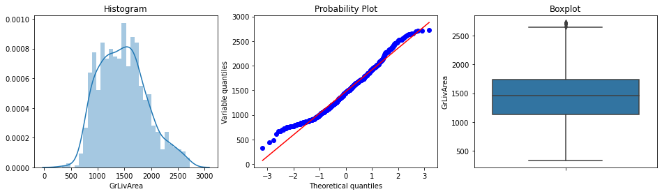

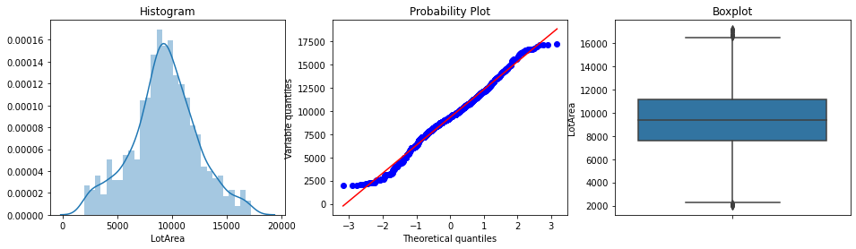

```python
diagnostic_plots(X_train_trimmed, 'GrLivArea')
diagnostic_plots(X_train_trimmed, 'LotArea')
```

### 6. Feature Scaling

Feature scaling refers to the methods used to normalize the range of values of independent variables. It is generally the last step in the Data Engineering Pipeline, performed just before training the machine learning algorithms.

**Methods:**

1. Standardisation
2. Mean Normalisation
3. Scaling to Maximum and Minimum
4. Scaling to absolute maximum
5. Scaling to unnit Norm

[figure not shown]

#### Standardisation

Standardisation involves centering the variable at zero, and standardising the variance to 1. The procedure involves subtracting the mean of each observation and then dividing by the standard deviation:

**z = (x - x_mean) / std**

The result of the above transformation is **z**, which is called the z-score, and represents how many standard deviations a given observation deviates from the mean.

```python
from sklearn.datasets import load_boston

boston_dataset = load_boston()

# create a dataframe with the independent variables
data = pd.DataFrame(boston_dataset.data,
                      columns=boston_dataset.feature_names)

# add target
data['MEDV'] = boston_dataset.target

data.head()
```

|  | CRIM | ZN | INDUS | CHAS | NOX | RM | AGE | DIS | RAD | TAX | PTRATIO | B | LSTAT | MEDV |
| --- | --- | --- | --- | --- | --- | --- | --- | --- | --- | --- | --- | --- | --- | --- |
| 0 | 0.00632 | 18.0 | 2.31 | 0.0 | 0.538 | 6.575 | 65.2 | 4.0900 | 1.0 | 296.0 | 15.3 | 396.90 | 4.98 | 24.0 |
| 1 | 0.02731 | 0.0 | 7.07 | 0.0 | 0.469 | 6.421 | 78.9 | 4.9671 | 2.0 | 242.0 | 17.8 | 396.90 | 9.14 | 21.6 |
| 2 | 0.02729 | 0.0 | 7.07 | 0.0 | 0.469 | 7.185 | 61.1 | 4.9671 | 2.0 | 242.0 | 17.8 | 392.83 | 4.03 | 34.7 |
| 3 | 0.03237 | 0.0 | 2.18 | 0.0 | 0.458 | 6.998 | 45.8 | 6.0622 | 3.0 | 222.0 | 18.7 | 394.63 | 2.94 | 33.4 |
| 4 | 0.06905 | 0.0 | 2.18 | 0.0 | 0.458 | 7.147 | 54.2 | 6.0622 | 3.0 | 222.0 | 18.7 | 396.90 | 5.33 | 36.2 |

```python
X_train, X_test, y_train, y_test = train_test_split(data.drop('MEDV', axis=1),
                                                    data['MEDV'],
                                                    test_size=0.3,
                                                    random_state=0)

X_train.shape, X_test.shape
```

```
((354, 13), (152, 13))
```

```python
# set up the scaler
scaler = StandardScaler()

# fit the scaler to the train set, it will learn the parameters
scaler.fit(X_train)

# transform train and test sets
X_train_scaled = scaler.transform(X_train)
X_test_scaled = scaler.transform(X_test)
```

```python
X_train_scaled = pd.DataFrame(X_train_scaled, columns=X_train.columns)
X_test_scaled = pd.DataFrame(X_test_scaled, columns=X_test.columns)
```

```python
np.round(X_train.describe(), 1)
```

|  | CRIM | ZN | INDUS | CHAS | NOX | RM | AGE | DIS | RAD | TAX | PTRATIO | B | LSTAT |
| --- | --- | --- | --- | --- | --- | --- | --- | --- | --- | --- | --- | --- | --- |
| count | 354.0 | 354.0 | 354.0 | 354.0 | 354.0 | 354.0 | 354.0 | 354.0 | 354.0 | 354.0 | 354.0 | 354.0 | 354.0 |
| mean | 3.4 | 11.8 | 11.1 | 0.1 | 0.6 | 6.3 | 69.0 | 3.8 | 9.4 | 401.8 | 18.5 | 360.6 | 12.4 |
| std | 8.4 | 23.7 | 7.0 | 0.2 | 0.1 | 0.7 | 28.0 | 2.1 | 8.7 | 170.6 | 2.2 | 85.6 | 7.1 |
| min | 0.0 | 0.0 | 0.5 | 0.0 | 0.4 | 3.6 | 2.9 | 1.2 | 1.0 | 187.0 | 12.6 | 0.3 | 1.7 |
| 25% | 0.1 | 0.0 | 5.0 | 0.0 | 0.4 | 5.9 | 45.2 | 2.1 | 4.0 | 276.0 | 17.4 | 376.1 | 6.7 |
| 50% | 0.3 | 0.0 | 8.6 | 0.0 | 0.5 | 6.2 | 79.4 | 3.2 | 5.0 | 311.0 | 19.1 | 391.6 | 11.2 |
| 75% | 3.1 | 20.0 | 18.1 | 0.0 | 0.6 | 6.6 | 93.8 | 5.1 | 24.0 | 666.0 | 20.2 | 395.7 | 16.7 |
| max | 89.0 | 100.0 | 27.7 | 1.0 | 0.9 | 8.8 | 100.0 | 12.1 | 24.0 | 711.0 | 22.0 | 396.9 | 37.0 |

```python
np.round(X_train_scaled.describe(), 1)
```

|  | CRIM | ZN | INDUS | CHAS | NOX | RM | AGE | DIS | RAD | TAX | PTRATIO | B | LSTAT |
| --- | --- | --- | --- | --- | --- | --- | --- | --- | --- | --- | --- | --- | --- |
| count | 354.0 | 354.0 | 354.0 | 354.0 | 354.0 | 354.0 | 354.0 | 354.0 | 354.0 | 354.0 | 354.0 | 354.0 | 354.0 |
| mean | 0.0 | 0.0 | -0.0 | 0.0 | -0.0 | -0.0 | 0.0 | 0.0 | 0.0 | -0.0 | 0.0 | -0.0 | -0.0 |
| std | 1.0 | 1.0 | 1.0 | 1.0 | 1.0 | 1.0 | 1.0 | 1.0 | 1.0 | 1.0 | 1.0 | 1.0 | 1.0 |
| min | -0.4 | -0.5 | -1.5 | -0.3 | -1.5 | -3.9 | -2.4 | -1.3 | -1.0 | -1.3 | -2.6 | -4.2 | -1.5 |
| 25% | -0.4 | -0.5 | -0.9 | -0.3 | -0.9 | -0.6 | -0.9 | -0.8 | -0.6 | -0.7 | -0.5 | 0.2 | -0.8 |
| 50% | -0.4 | -0.5 | -0.4 | -0.3 | -0.2 | -0.1 | 0.4 | -0.3 | -0.5 | -0.5 | 0.3 | 0.4 | -0.2 |
| 75% | -0.0 | 0.3 | 1.0 | -0.3 | 0.6 | 0.5 | 0.9 | 0.6 | 1.7 | 1.6 | 0.8 | 0.4 | 0.6 |
| max | 10.3 | 3.7 | 2.4 | 3.8 | 2.7 | 3.5 | 1.1 | 4.1 | 1.7 | 1.8 | 1.6 | 0.4 | 3.5 |